# Irene-Data Analysis Progress

Mwaura Patrick

2/1/2021

### Irene Data Analysis

This analysis is being done at the request of the researcher

### Number of camels from each of the Livestock Production System

With their Percentages and Bar Graph

Ranch vs Livestock production system With Percentages

| Community | Extensive | Intensive | Total |
| --- | --- | --- | --- |
| Ilmotiok | 100% (118) | 0% (0) | 42% (118) |
| Loisaba Ranch | 0% (0) | 34% (55) | 20% (55) |
| Mpala Ranch | 0% (0) | 48% (79) | 28% (79) |
| Suyian Ranch | 0% (0) | 18% (30) | 11% (30) |
| Total | 100% (118) | 100% (164) | 100% (282) |

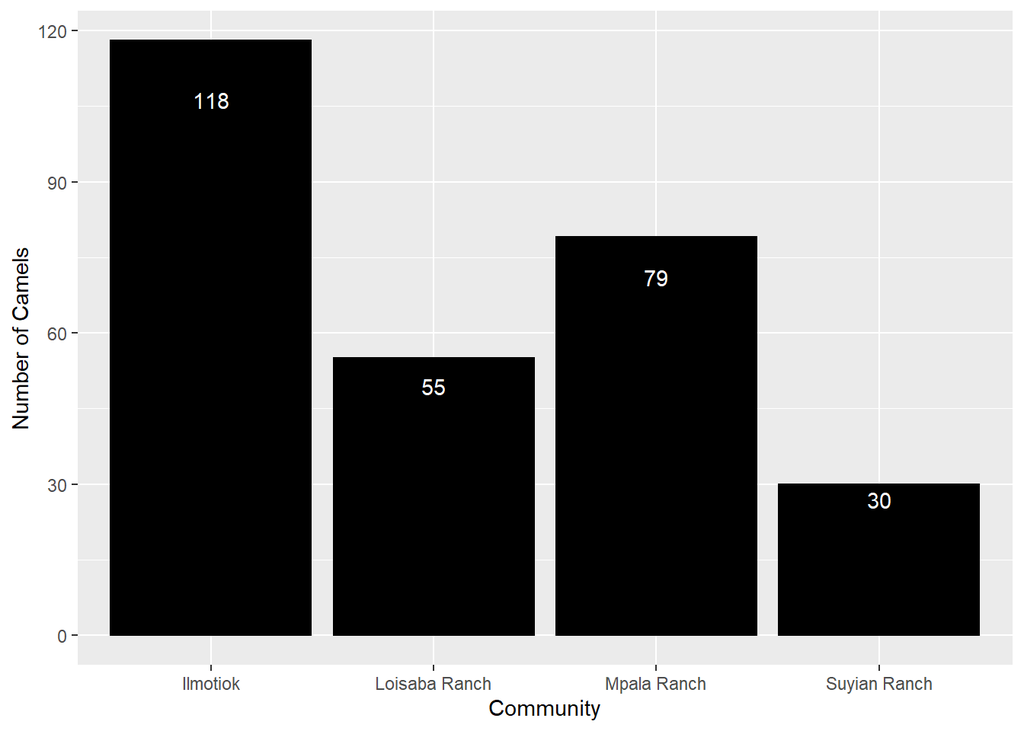

### Counts and Percentages of E.coli Isolated from all the camels This table counts and percentages of E.coli isolates in Extensive/Intensive location/Livestock procuction system

E.coli recovered from each of the LPS

| mo | Extensive | Intensive | Total |
| --- | --- | --- | --- |
| Escherichia coli | 40% (47) | 45% (74) | 43% (121) |
| Others | 60% (71) | 55% (90) | 57% (161) |

###Pie Chart The above table can be visualised as a pie chart

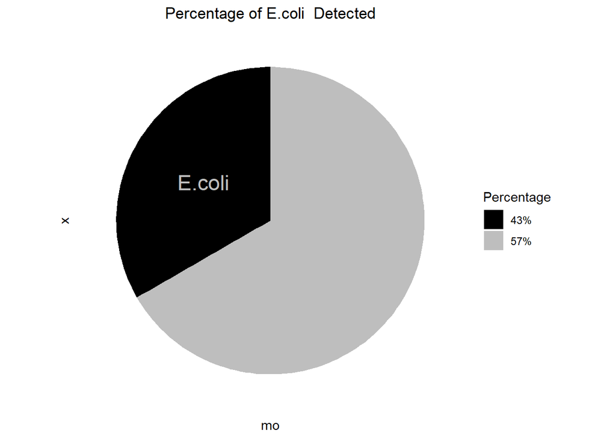

### Counts and percentages of the number of camels (female and male) from each livestock production system

Camels(Female and Male) from each of the LPS

| Gender | Extensive | Intensive |
| --- | --- | --- |
| Female | 48% (97) | 52% (104) |
| Male | 26% (21) | 74% (60) |

```
##
##  Pearson's Chi-squared test with Yates' continuity correction
##
## data:  .
## X-squared = 10.933, df = 1, p-value = 0.0009447
```

### The count and percentages of Resistance/Intermediate/Susceptible E.coli to all the antibiotics

Antibiotic Susceptability Intermediate and Resistance

| antibiotic | S | I | R |
| --- | --- | --- | --- |
| Amoxicillin/clavulanic acid | 99% | 1% | 0% |
| Ampicillin | 84% | 6% | 10% |
| Cefaclor | 22% | 49% | 29% |
| Cefepime | 74% | 22% | 3% |
| Cefotaxime | 60% | 24% | 17% |
| Ceftazidime | 68% | 24% | 8% |
| Ceftriaxone | 89% | 7% | 3% |
| Cefuroxime | 83% | 13% | 4% |
| Chloramphenicol | 100% | 0% | 0% |
| Ciprofloxacin | 61% | 37% | 2% |
| Gentamicin | 90% | 9% | 1% |
| Norfloxacin | 100% | 0% | 0% |
| Spectinomycin | 90% | 7% | 2% |
| Tetracycline | 93% | 2% | 5% |
| Trimethoprim/sulfamethoxazole | 96% | 1% | 3% |

### Beta-lactams/penicillins

Beta-lactam antibiotics are one of the most commonly prescribed drug classes with numerous clinical indications.

From a biochemical point of view, these drugs have a common feature, which is the 3-carbon and 1-nitrogen ring (beta-lactam ring) that is highly reactive. This class includes:

Penicillins,Cephalosporins,Carbapenems,Monobactams,Beta-lactamase inhibitors

Beta-lactams/penicillins

| antibiotic | S | I | R |
| --- | --- | --- | --- |
| Ampicillin | 84% (102) | 6% (7) | 10% (12) |
| Cefaclor | 22% (27) | 49% (59) | 29% (35) |
| Cefepime | 74% (90) | 22% (27) | 3% (4) |
| Cefotaxime | 60% (72) | 24% (29) | 17% (20) |
| Ceftazidime | 68% (82) | 24% (29) | 8% (10) |
| Ceftriaxone | 89% (108) | 7% (9) | 3% (4) |
| Cefuroxime | 83% (100) | 13% (16) | 4% (5) |

### Resisitance

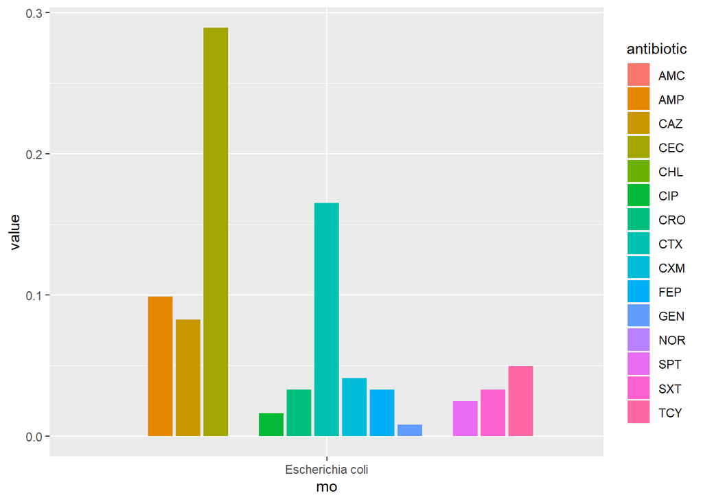

```
##                    interpretation          S          I          R
## LPS       variable
## Extensive AMC                     1.00000000 0.00000000 0.00000000
##           AMP                     0.82978723 0.08510638 0.08510638
##           CAZ                     0.55319149 0.34042553 0.10638298
##           CEC                     0.19148936 0.46808511 0.34042553
##           CHL                     1.00000000 0.00000000 0.00000000
##           CIP                     0.63829787 0.36170213 0.00000000
##           CRO                     0.91489362 0.06382979 0.02127660
##           CTX                     0.57446809 0.25531915 0.17021277
##           CXM                     0.82978723 0.14893617 0.02127660
##           FEP                     0.76595745 0.21276596 0.02127660
##           GEN                     0.87234043 0.10638298 0.02127660
##           NOR                     1.00000000 0.00000000 0.00000000
##           SPT                     0.93617021 0.04255319 0.02127660
##           SXT                     0.97872340 0.00000000 0.02127660
##           TCY                     0.97872340 0.02127660 0.00000000
## Intensive AMC                     0.98648649 0.01351351 0.00000000
##           AMP                     0.85135135 0.04054054 0.10810811
##           CAZ                     0.75675676 0.17567568 0.06756757
##           CEC                     0.24324324 0.50000000 0.25675676
##           CHL                     1.00000000 0.00000000 0.00000000
##           CIP                     0.59459459 0.37837838 0.02702703
##           CRO                     0.87837838 0.08108108 0.04054054
##           CTX                     0.60810811 0.22972973 0.16216216
##           CXM                     0.82432432 0.12162162 0.05405405
##           FEP                     0.72972973 0.22972973 0.04054054
##           GEN                     0.91891892 0.08108108 0.00000000
##           NOR                     1.00000000 0.00000000 0.00000000
##           SPT                     0.87837838 0.09459459 0.02702703
##           SXT                     0.94594595 0.01351351 0.04054054
##           TCY                     0.90540541 0.01351351 0.08108108
```

### Multdrug Resistance Organisms MDR

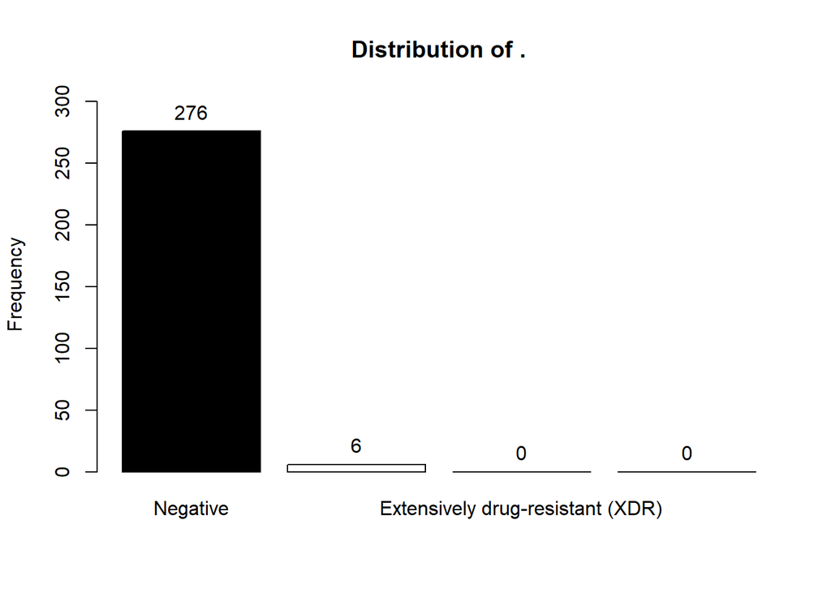

Multdrug Resistance Organisms MDR

[output not shown]

|  | Frequency | Percent |
| --- | --- | --- |
| Negative | 276 | 97.9 |
| Multi-drug-resistant (MDR) | 6 | 2.1 |
| Extensively drug-resistant (XDR) | 0 | 0.0 |
| Pandrug-resistant (PDR) | 0 | 0.0 |
| Total | 282 | 100.0 |

### Antibiotic Profiling

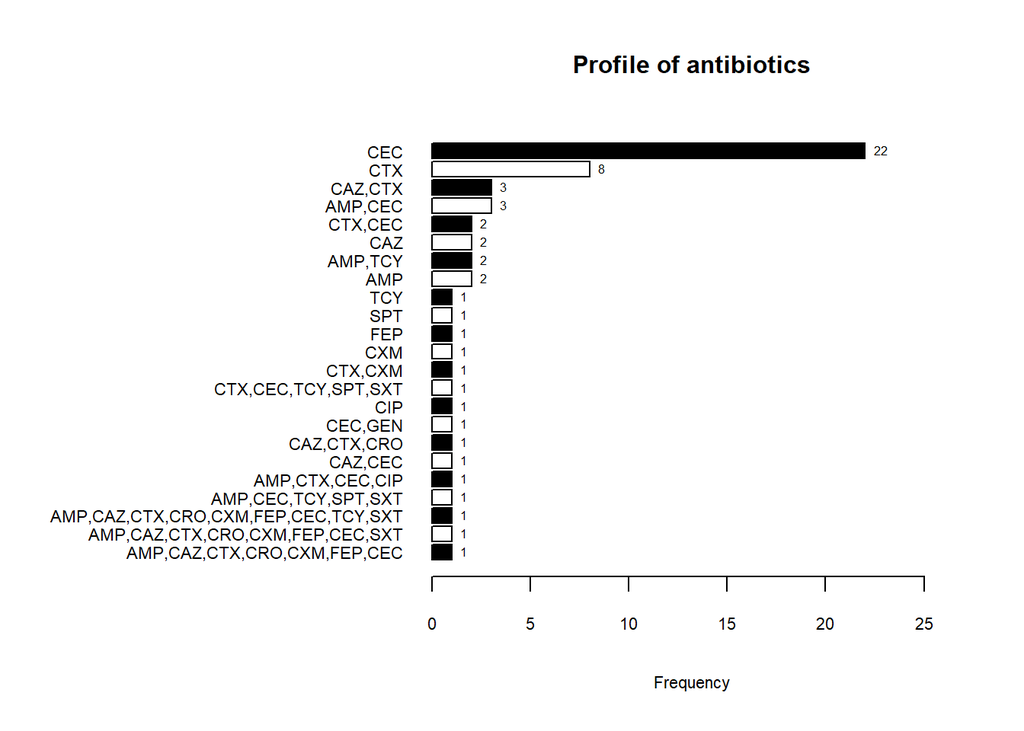

Profile of antibiotics

[output not shown]

|  | Frequency | Percent |
| --- | --- | --- |
| CEC | 22 | 37.3 |
| CTX | 8 | 13.6 |
| CAZ,CTX | 3 | 5.1 |
| AMP,CEC | 3 | 5.1 |
| CTX,CEC | 2 | 3.4 |
| CAZ | 2 | 3.4 |
| AMP,TCY | 2 | 3.4 |
| AMP | 2 | 3.4 |
| TCY | 1 | 1.7 |
| SPT | 1 | 1.7 |
| FEP | 1 | 1.7 |
| CXM | 1 | 1.7 |
| CTX,CXM | 1 | 1.7 |
| CTX,CEC,TCY,SPT,SXT | 1 | 1.7 |
| CIP | 1 | 1.7 |
| CEC,GEN | 1 | 1.7 |
| CAZ,CTX,CRO | 1 | 1.7 |
| CAZ,CEC | 1 | 1.7 |
| AMP,CTX,CEC,CIP | 1 | 1.7 |
| AMP,CEC,TCY,SPT,SXT | 1 | 1.7 |
| AMP,CAZ,CTX,CRO,CXM,FEP,CEC,TCY,SXT | 1 | 1.7 |
| AMP,CAZ,CTX,CRO,CXM,FEP,CEC,SXT | 1 | 1.7 |
| AMP,CAZ,CTX,CRO,CXM,FEP,CEC | 1 | 1.7 |
| Total | 59 | 100.0 |